# Testes Não Paramétricos

Análise de Dados Ambientais · Aula 17

Prof. Dr. Luiz Diego Vidal Santos

# TESTES NÃO-PARAMÉTRICOS

## TESTES NÃO-PARAMÉTRICOS

Testes de Comparação de Grupos

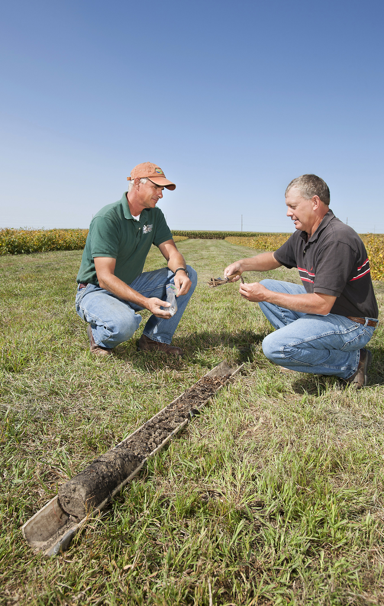

Pesquisa agrícola em campo

TESTES NÃO-PARAMÉTRICOS

DE DIFERENÇAS DE GRUPOS

O que são:

- Testes não paramétricos são utilizados quando os pressupostos dos testes paramétricos não são acatados:
  - Distribuição normal
  - Homogeneidade de variância Vantagens
- Possui menos pressupostos e mais simples
- Lógica matemática incrivelmente simples
- Estrutura dos dados mais simples (e realista)
- Possibilidade de utilização do teste em amostras muito pequenas

Entendendo as equivalências entre os testes

TESTES NÃO-PARAMÉTRICOS

DE DIFERENÇAS DE GRUPOS

| Paramétricos | Não-paramétricos |
| --- | --- |
| Teste t para amostras independentes | Mann-Whitney |
| Análise de Variância | Kruskal-Wallis |
| Teste t para amostras dependentes | Wilcoxon Signed Rank |
| Análise de Variância de Medidas Repetidas | ANOVA de Friedman |

Algumas questões iniciais importantes:

- Testes não-paramétricos não utilizam os escores originais dos repetições;
- Fazem uma reorganização em torno de rank (posicionamento) e atribui novos valores em termos de ordenação do rank;
- Estatísticas de Média e Desvio-Padrão perdem o sentido, de modo que é importante apresentar outras informações da análise, quando se reporta os resultados. TESTES NÃO-PARAMÉTRICOS

DE DIFERENÇAS DE GRUPOS

## MANN-WHITNEY

Comparação entre dois grupos independentes

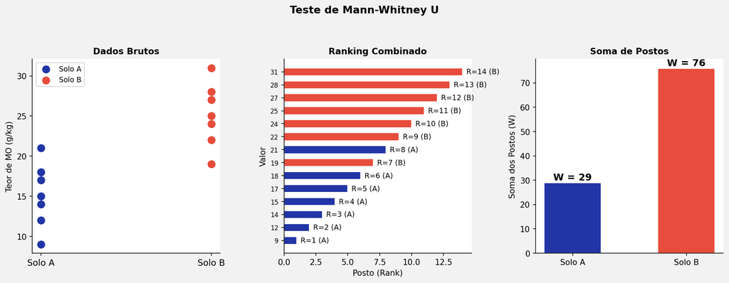

Teste de Mann-Whitney: dados brutos, ranking e soma de postos

MANN-WHITNEY

DOIS GRUPOS INDEPENDENTES

Comparação de 2 grupos independentes

- Substitui o teste *t** *de Student

| Sujeito | Tratamento | Escore |
| --- | --- | --- |
| 1 | A | 4 |
| 2 | B | 6 |
| 3 | A | 5 |
| 4 | B | 9 |
| 5 | B | 7 |
| 6 | A | 11 |
| 7 | B | 11 |
| 8 | A | 5 |
| 9 | B | 13 |
| 10 | A | 12 |

Soma de postos:

Grupo A: 22,5

Grupo B: 32,5

MANN-WHITNEY

DOIS GRUPOS INDEPENDENTES

| Tratamento | Escore | Posto | Posto Real |
| --- | --- | --- | --- |
| A | 4 | 1 | 1 |
| A | 5 | 2 | 2,5 |
| A | 5 | 3 | 2,5 |
| B | 6 | 4 | 4 |
| B | 7 | 5 | 5 |
| B | 9 | 6 | 6 |
| A | 11 | 7 | 7,5 |
| B | 11 | 8 | 7,5 |
| A | 12 | 9 | 9 |
| B | 13 | 10 | 10 |

Cálculo do Mann-Whitney

é menor que 20)

*Onde:*

U = estatística a ser calculada;

*N = número de participantes por grupo*

*R = valor da soma dos postos*

*U = 25 + 5(6) - 22,5 =** 17,5*

*U**B** **=** **25** **+** **5(6)** **-** **32,5** **=** 7,5*

MANN-WHITNEY

DOIS GRUPOS INDEPENDENTES

MANN-WHITNEY

DOIS GRUPOS INDEPENDENTES

Opções alternativas do Mann-Whitney

- Kolmogorov-Smirnov Z: Maior poder quando N < 25 por grupo;
- Moses Extreme Reaction: Compara a variabilidade dos escores entre os grupos (relativamente semelhante a um teste de homogeneidade de variância)
- Wald-Wolfowitz runs: A derivação de significância é um pouco diferente do Mann-Whitney. Aqui, se avalia a ordenação dos postos e não a sua soma. Raramente utilizado. MANN-WHITNEY

DOIS GRUPOS INDEPENDENTES

## KRUSKAL-WALLIS

Comparação entre três (ou +) grupos independentes

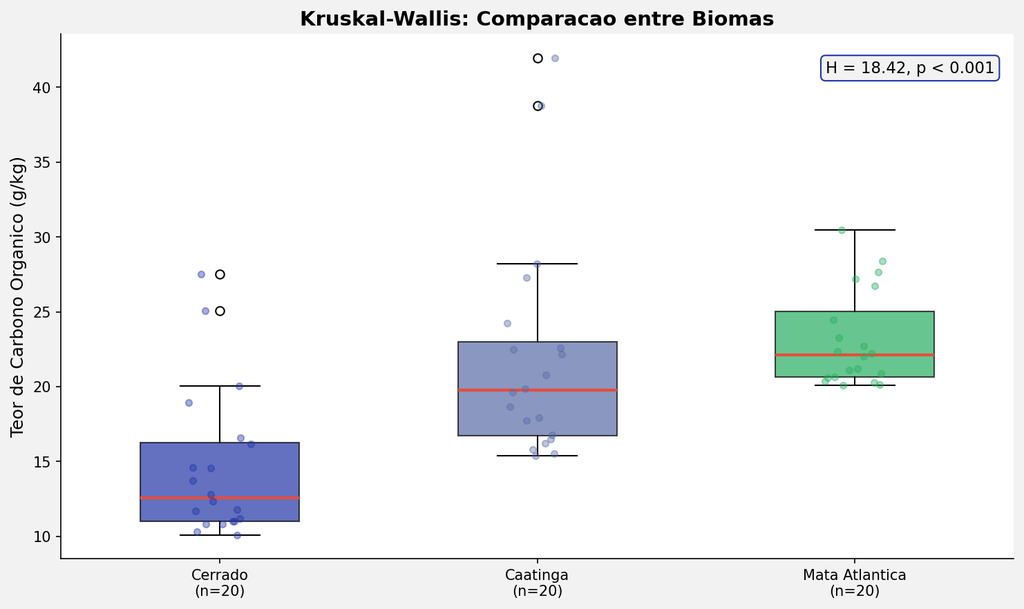

Kruskal-Wallis: comparação entre biomas

Kruskall-Wallis

- Substitui a Análise de Variância (ANOVA) para comparar 3 ou + grupos; Soma de postos: Grupo A: 16

Grupo B: 20

Grupo C: 19

A estatística H é calculada, considerando a soma de postos de cada

grupo, ponderando pelo total de participantes por grupo (N);

A significância do teste de Kruskall-Wallis é baseada na tabela de significância do qui-quadrado, e portanto, leva em consideração os graus de liberdade (kgrupos - 1)

| Tratamento | Escore | Posto | Posto Real |
| --- | --- | --- | --- |
| A | 4 | 1 | 1 |
| C | 5 | 2 | 2,5 |
| B | 5 | 3 | 2,5 |
| C | 6 | 4 | 4 |
| C | 7 | 5 | 5 |
| A | 9 | 6 | 6 |
| B | 11 | 7 | 7,5 |
| C | 11 | 8 | 7,5 |
| A | 12 | 9 | 9 |
| B | 13 | 10 | 10 |

Kruskall-Wallis

- Na medida que o valor de H é estatisticamente significativo, isso significa que existem diferenças entre os grupos
- Segunda etapa: achar as diferenças (*pairwise comparisons*)
  - G1 com G2
  - G1 com G3
  - G2 com G3
- Controle do Erro Tipo I
  - SPSS calcula o p-valor ajustado para a quantidade de comparações; MANN-WHITNEY

## WILCOXON SIGNED-RANK

Comparação entre dois grupos dependents (medidas repetidas)

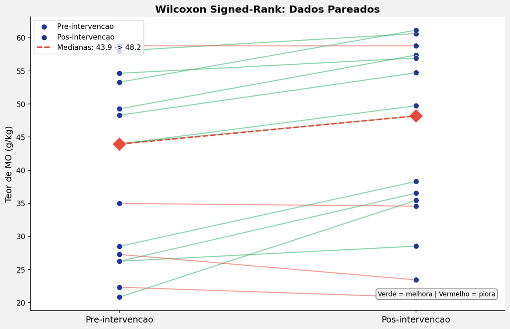

Wilcoxon Signed-Rank: dados pareados pré-pós

WILCOXON SIGNED-RANK

DOIS GRUPOS DEPENDENTES

Wilcoxon Signed Rank Test (1947): Substitui o Teste t de Student para Medidas

Repetidas

Comparação nos escores entre um grupo que respondeu à pesquisa duas vezes

**Estresse**

**Estresse**

Wilcoxon Signed Rank Test (1947)

```
            - Postos são ordenados;
```

Empates (Diff = 0) são excluídos;

O sinal da diferença (positivo ou negativo) é considerada no rankeamento;

É calculada uma soma dos ranks positivos (T+) e negativos (T-);

A estatística *T** *geral e o erro padrão é computado;

Escore *T** *é transformado em um escore Z para se avaliar a significância estatística.

WILCOXON SIGNED-RANK

DOIS GRUPOS DEPENDENTES

| Sujeito | Pré | Pós | Diff | Sinal |
| --- | --- | --- | --- | --- |
| 1 | 5 | 7 | 2 | + |
| 2 | 6 | 6 | 0 | Tie |
| 3 | 2 | 3 | 1 | + |
| 4 | 4 | 8 | 4 | + |
| 5 | 6 | 7 | 1 | + |
| 6 | 7 | 6 | 1 | - |
| 7 | 3 | 7 | 4 | + |
| 8 | 5 | 8 | 3 | + |
| 9 | 5 | 5 | 0 | Tie |
| 10 | 5 | 8 | 3 | + |

## ANOVA DE FRIEDMAN

Comparação entre três ou + grupos dependentes (medidas repetidas)

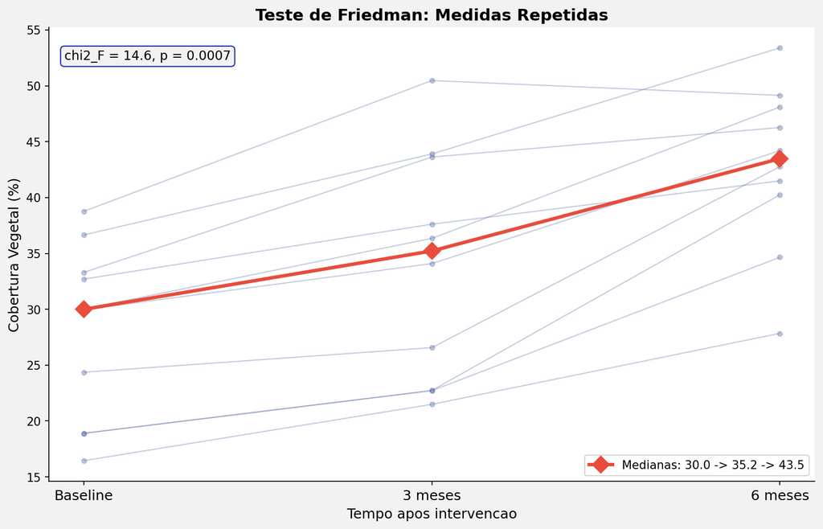

Teste de Friedman: trajetórias de medidas repetidas

ANOVA DE FRIEDMAN

TRÊS GRUPOS DEPENDENTES

ANOVA de Friedman: Substitui a ANOVA de Medidas Repetidas

| Sujeito | Pré | Pós | Follow-up | Rank_Pré | Rank_Pós | Rank_Follow |
| --- | --- | --- | --- | --- | --- | --- |
| 1 | 7 | 6 | 8 | 2 | 1 | 3 |
| 2 | 5 | 6 | 8 | 1 | 2 | 3 |
| 3 | 2 | 3 | 5 | 1 | 2 | 3 |
| 4 | 6 | 7 | 8 | 1 | 2 | 3 |
| 5 | 7 | 6 | 4 | 3 | 2 | 1 |
| 6 | 5 | 7 | 9 | 1 | 2 | 3 |
| 7 | 5 | 8 | 6 | 1 | 3 | 2 |
| 8 | 5 | 8 | 9 | 1 | 2 | 3 |
| 9 | 4 | 8 | 5 | 1 | 3 | 2 |
| 10 | 3 | 6 | 7 | 1 | 2 | 3 |
| Soma |  |  |  | 13 | 21 | 26 |

Obrigado!

Luiz Diego Vidal Santos

Universidade Estadual de Feira de Santana (UEFS)